# Star Tribune analysis of Minnesota sexual assault investigations

MaryJo Webster, Brandon Stahl, Jennifer Bjorhus

Last updated: 2018-12-27

# Cases reviewed

The Star Tribune requested, from 20 law enforcement agencies statewide, investigative reports on rapes reported in 2015 and 2016. We have about half the cases we expected and are waiting on the others. Below is a breakdown of the cases we’ve reviewed from Minneapolis, St. Paul and the other agencies, so far.

| dept | Number_cases |
| --- | --- |
| All other | 671 |
| Minneapolis | 554 |
| St. Paul | 240 |
| Total | 1465 |

# Analysis results

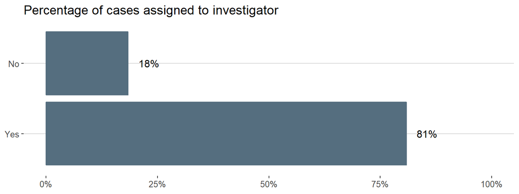

## Percent of cases sent for prosecution

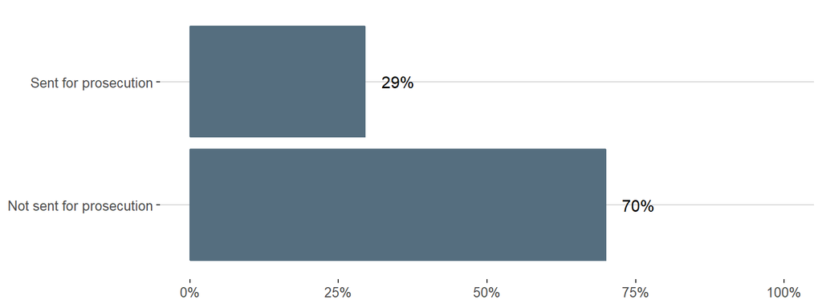

## Percent of cases where charges were filed

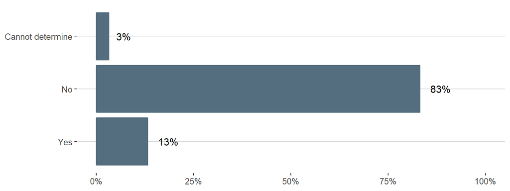

## Percent of cases resulting in conviction

Less than 1 in 10 of the cases we reviewed resulted in conviction.

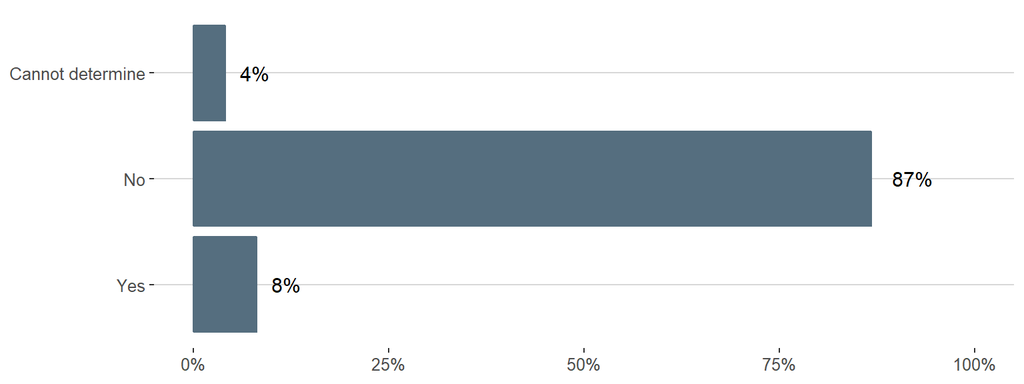

# Case investigations

The charts below look at how often investigators took basic policing steps in the cases we reviewed.

A recommended best practice is for investigators to conduct a more thorough interview after the victim makes an initial report to the officer responding to the initial call.

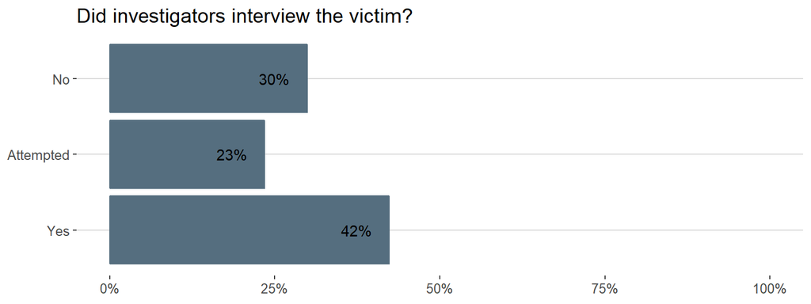

About 70% of the cases we reviewed listed one or more suspect names in the report, yet investigators failed to interview that person more often than not.

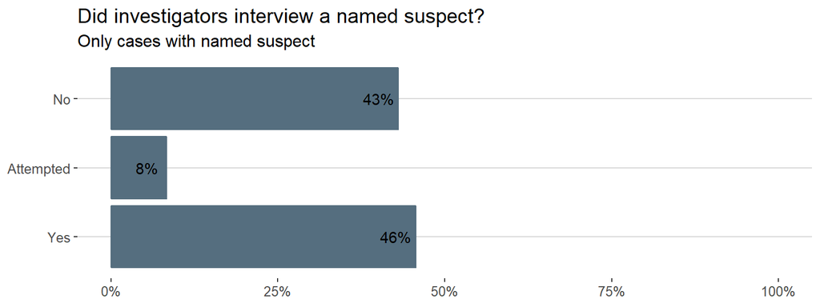

When reviewing cases, we looked for indications of evidence that could’ve been collected but there was no documentation in the report that it was. This might have included DNA, clothing or bed sheets, surveillance video or cell phone data.

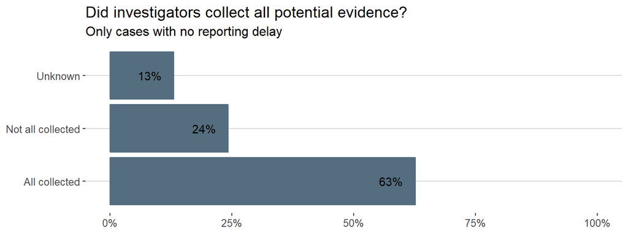

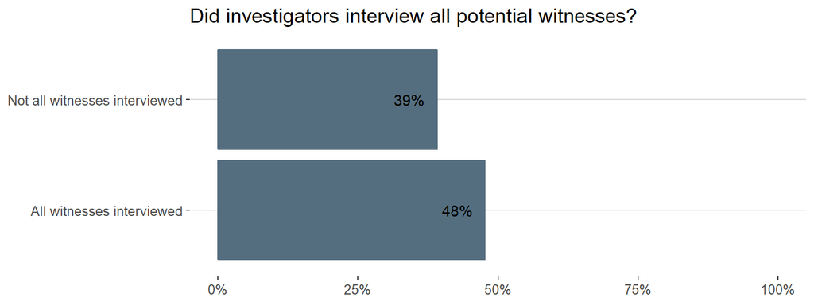

# Cases not sent for prosecution

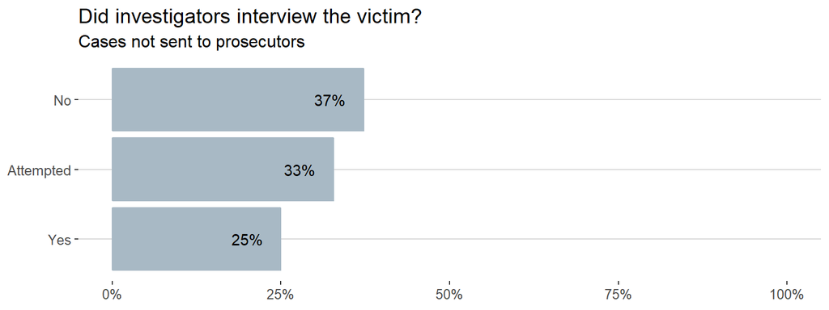

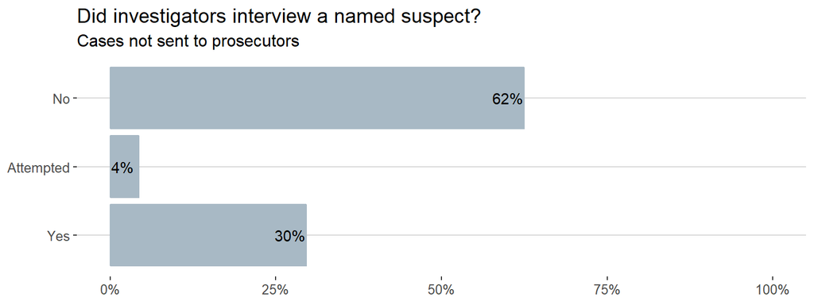

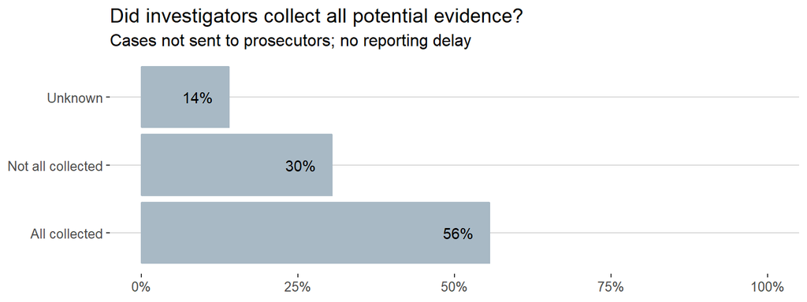

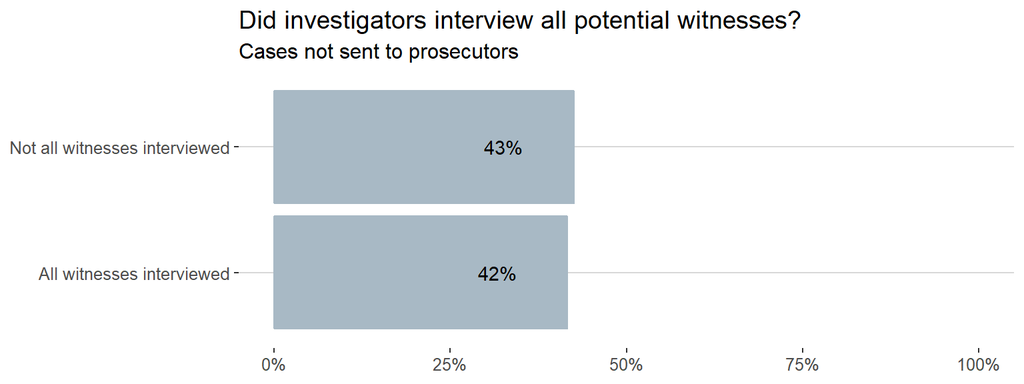

# Victim involvement

About one-third of victims either choose to no longer cooperate in an investigation or police are unable to reach them later in the investigation.

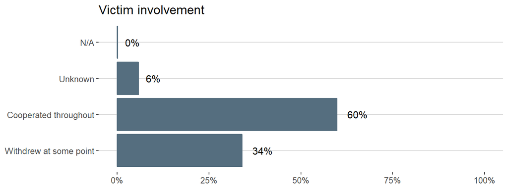

When a victim stays involved in the investigation, the case is far more likely to be sent to prosecutors.

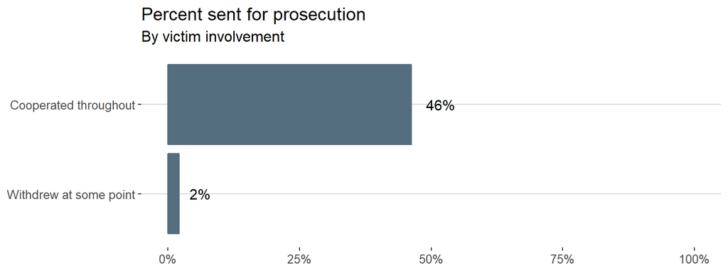

And we’ve only found 1 case that resulted in a conviction after the victim dropped out.

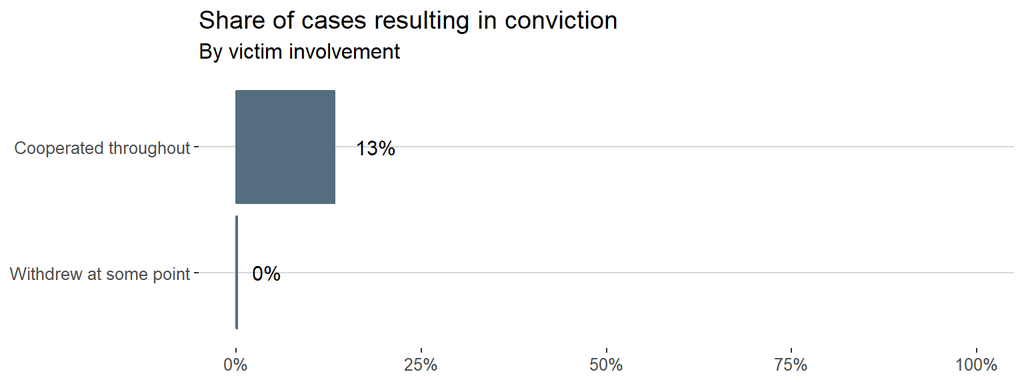